# Análise de variância com mais de uma variável resposta

Análise de variância com mais de uma variável resposta Gleynner Ghiotto

**Exercício proposto:** a prática de fazer churrasco é um habito comum entre os brasileiros aos finais de semana e datas comemorativas. Porém, nem sempre esse costume é amigo do meio ambiente, pois a grande maioria utiliza o carvão para se obter a brasa e, quando queimado, o carvão libera umagrande quantidade de poluentes na atmosfera. Dessa forma, um churrasqueiro está testando qual carvão trará mais benefícios na hora de realizar seu trabalho. Cada dado é referente a 5 kg de carvão.

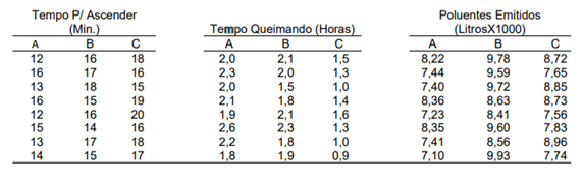

1. Faça as análises de de variâncias e estudo das médias.
2. Com os resultados das três características analisadas, tente formular uma conclusão.

# 1 Dados do Problema

```r
Tempo_acender <- data.frame(A = c(12,16,13,16,12,15,13,14),
                            B = c(16,17,18,15,16,14,17,15),
                            C = c(18,16,15,19,20,16,18,17)) %>%
                 gather(key = trat,value = y,1:3)
Tempo_acender$trat <- as.factor(Tempo_acender$trat)
resd_tempAcender <- residuals(lm(Tempo_acender$y ~ Tempo_acender$trat))
Tempo_acender <- cbind(Tempo_acender,resd_tempAcender)
head(Tempo_acender)
```

|  | trat | y | resd_tempAcender |
| --- | --- | --- | --- |
| 1 | A | 12 | -1.875 |
| 2 | A | 16 | 2.125 |
| 3 | A | 13 | -0.875 |
| 4 | A | 16 | 2.125 |
| 5 | A | 12 | -1.875 |
| 6 | A | 15 | 1.125 |

```r
Tempo_queimando <- data.frame(A = c(2,2.3,2,2.1,1.9,2.6,2.2,1.8),
                              B = c(2.1,2,1.5,1.8,2.1,2.3,1.8,1.9),
                              C = c(1.5,1.3,1,1.4,1.6,1.3,1,0.9)) %>%
                   gather(trat,y,1:3)
Tempo_queimando$trat <- as.factor(Tempo_queimando$trat)
resd_tempQueimando <- residuals(lm(Tempo_queimando$y ~ Tempo_queimando$trat))
Tempo_queimando <- cbind(Tempo_queimando,resd_tempQueimando)
head(Tempo_queimando)
```

|  | trat | y | resd_tempQueimando |
| --- | --- | --- | --- |
| 1 | A | 2.0 | -0.1125 |
| 2 | A | 2.3 | 0.1875 |
| 3 | A | 2.0 | -0.1125 |
| 4 | A | 2.1 | -0.0125 |
| 5 | A | 1.9 | -0.2125 |
| 6 | A | 2.6 | 0.4875 |

```r
Poluentes_emitidos <- data.frame(A = c(8.22,7.44,7.4,8.36,7.23,8.35,7.41,7.1),
                                 B = c(9.78,9.59,9.72,8.63,8.41,9.6,8.56,9.93),
                                 C = c(8.72,7.65,8.85,8.73,7.56,7.83,8.96,7.74)) %>%
                      gather(trat,y,1:3)
Poluentes_emitidos$trat <- as.factor(Poluentes_emitidos$trat)
resd_poluEmit <- residuals(lm(Poluentes_emitidos$y ~ Poluentes_emitidos$trat))
Poluentes_emitidos <- cbind(Poluentes_emitidos,resd_poluEmit)
head(Poluentes_emitidos)
```

|  | trat | y | resd_poluEmit |
| --- | --- | --- | --- |
| 1 | A | 8.22 | 0.53125 |
| 2 | A | 7.44 | -0.24875 |
| 3 | A | 7.40 | -0.28875 |
| 4 | A | 8.36 | 0.67125 |
| 5 | A | 7.23 | -0.45875 |
| 6 | A | 8.35 | 0.66125 |

# 2 Verificação das pressuposições

## 2.1 Os resíduos apresentam distribuição Normal

- **Teste de normalidade para tempo gasto para acender**

```r
shapiro.test(resd_tempAcender)
```

```
    Shapiro-Wilk normality test

data:  resd_tempAcender
W = 0.95421, p-value = 0.3333
```

Valor de *p* igual a 0,3333 (*p* > 0,05), logo, não significativo. Isto indica que os dados seguem distribuição normal (hipótese H<sub>0</sub> é verdadeira).

- **Teste de normalidade para o tempo de queima**

```r
shapiro.test(resd_tempQueimando)
```

```
    Shapiro-Wilk normality test

data:  resd_tempQueimando
W = 0.9841, p-value = 0.9578
```

Valor de *p* igual a 0,9578 (*p* > 0,05), logo, os dados seguem distribuição normal (hipótese H<sub>0</sub> é verdadeira).

- **Teste de normalidade para os poluentes emitidos**

```r
shapiro.test(resd_poluEmit)
```

```
    Shapiro-Wilk normality test

data:  resd_poluEmit
W = 0.85707, p-value = 0.002966
```

## 2.2 Homogeneidade de variâncias dos resíduos

- **Teste de homogeneidade de variâncias para tempo gasto para acender**

```r
bartlett.test(resd_tempAcender ~ trat, data = Tempo_acender)
```

```
    Bartlett test of homogeneity of variances

data:  resd_tempAcender by trat
Bartlett's K-squared = 0.47845, df = 2, p-value = 0.7872
```

Valor *p* > 0,05, logo, o teste é não signicativo (isto é, as variâncias amostrais são homogêneas).

- **Teste de homogeneidade de variâncias para tempo de queima**

```r
bartlett.test(resd_tempQueimando ~ trat, data = Tempo_queimando)
```

```
    Bartlett test of homogeneity of variances

data:  resd_tempQueimando by trat
Bartlett's K-squared = 0.0155, df = 2, p-value = 0.9923
```

Valor *p* > 0,05, logo, as variâncias amostrais são homogêneas.

- **Teste de homogeneidade de variâncias para os poluentes emitidos**

```r
bartlett.test(resd_poluEmit ~ trat, data = Poluentes_emitidos)
```

```
    Bartlett test of homogeneity of variances

data:  resd_poluEmit by trat
Bartlett's K-squared = 0.218, df = 2, p-value = 0.8967
```

Valor *p* > 0,05, logo, o teste é não signicativo.

## 2.3 Os erros aleatórios sejam independentes

O uso da casualização na distribuição das amostras experimentais faz com que a estimativa do erro experimental tenha validade, além de fazer com que as amostras sejam independentes.

# 3 Análise de variância (ANOVA)

## 3.1 ANOVA para o tempo gasto para acender

```r
ANOVA_DIC_TempAc <- aov(y ~ trat, data = Tempo_acender)
Saida_DIC_TempAc <- summary(ANOVA_DIC_TempAc);Saida_DIC_TempAc
```

```
            Df Sum Sq Mean Sq F value   Pr(>F)
trat         2  49.75  24.875   10.29 0.000766 ***
Residuals   21  50.75   2.417
---
Signif. codes:  0 '***' 0.001 '**' 0.01 '*' 0.05 '.' 0.1 ' ' 1
```

Valor de *p* igual a 0,000766 (*p* ≤ 0,05), logo, o teste é significativo. Isto indica que pelo menos uma das médias dos tratamentos difere das demais.

```r
#str(Saida_DIC_TempAc)
str(Saida_DIC_TempAc[[1]])
```

```
Classes 'anova' and 'data.frame':   2 obs. of  5 variables:
 $ Df     : num  2 21
 $ Sum Sq : num  49.8 50.8
 $ Mean Sq: num  24.88 2.42
 $ F value: num  10.3 NA
 $ Pr(>F) : num  0.000766 NA
```

```r
sq.res <- Saida_DIC_TempAc[[1]]$`Sum Sq`[2]
gl.res <- Saida_DIC_TempAc[[1]]$Df[2]

tukey(Tempo_acender$y,Tempo_acender$trat,
      DFerror = gl.res,
      SSerror = sq.res,
      alpha = 0.05)
```

```
Teste de Tukey
------------------------------------------------------------------------
Grupos Tratamentos Medias
a    C   17.375
a    B   16
 b   A   13.875
------------------------------------------------------------------------
```

## 3.2 ANOVA para o tempo de queima

```r
ANOVA_TempQ <- aov(y ~ trat, data = Tempo_queimando)
Saida_DIC_TempQ <- summary(ANOVA_TempQ);Saida_DIC_TempQ
```

```
            Df Sum Sq Mean Sq F value   Pr(>F)
trat         2  3.326  1.6629   26.31 1.91e-06 ***
Residuals   21  1.327  0.0632
---
Signif. codes:  0 '***' 0.001 '**' 0.01 '*' 0.05 '.' 0.1 ' ' 1
```

Valor de *p* igual a 1,91e-06 (*p* ≤ 0,05), logo, o teste indica que pelo menos uma das médias amostrais difere das demais.

```r
#str(Saida_DIC_TempQ)
str(Saida_DIC_TempQ[[1]])
```

```
Classes 'anova' and 'data.frame':   2 obs. of  5 variables:
 $ Df     : num  2 21
 $ Sum Sq : num  3.33 1.33
 $ Mean Sq: num  1.6629 0.0632
 $ F value: num  26.3 NA
 $ Pr(>F) : num  1.91e-06 NA
```

```r
sq.res <- Saida_DIC_TempQ[[1]]$`Sum Sq`[2]
gl.res <- Saida_DIC_TempQ[[1]]$Df[2]

tukey(Tempo_queimando$y,Tempo_queimando$trat,
      DFerror = gl.res,
      SSerror = sq.res,
      alpha = 0.05)
```

```
Teste de Tukey
------------------------------------------------------------------------
Grupos Tratamentos Medias
a    A   2.1125
a    B   1.9375
 b   C   1.25
------------------------------------------------------------------------
```

## 3.3 ANOVA para o nível de poluentes emitidos

```r
ANOVA_PoluEmit <- aov(y ~ trat, data = Poluentes_emitidos)
Saida_DIC_PoluEmit <- summary(ANOVA_PoluEmit);Saida_DIC_PoluEmit
```

```
            Df Sum Sq Mean Sq F value   Pr(>F)
trat         2  10.37   5.187   14.92 9.29e-05 ***
Residuals   21   7.30   0.348
---
Signif. codes:  0 '***' 0.001 '**' 0.01 '*' 0.05 '.' 0.1 ' ' 1
```

Valor de *p* igual a 9,29e-05 (*p* ≤ 0,05), logo, o teste é significativo (pelo menos uma das médias difere das demais).

```r
#str(Saida_DIC_PoluEmit)
str(Saida_DIC_PoluEmit[[1]])
```

```
Classes 'anova' and 'data.frame':   2 obs. of  5 variables:
 $ Df     : num  2 21
 $ Sum Sq : num  10.4 7.3
 $ Mean Sq: num  5.187 0.348
 $ F value: num  14.9 NA
 $ Pr(>F) : num  9.29e-05 NA
```

```r
sq.res <- Saida_DIC_PoluEmit[[1]]$`Sum Sq`[2]
gl.res <- Saida_DIC_PoluEmit[[1]]$Df[2]

tukey(Poluentes_emitidos$y,Poluentes_emitidos$trat,
      DFerror = gl.res,
      SSerror = sq.res,
      alpha = 0.05)
```

```
Teste de Tukey
------------------------------------------------------------------------
Grupos Tratamentos Medias
a    B   9.2775
 b   C   8.255
 b   A   7.68875
------------------------------------------------------------------------
```

# 4 Conclusão

De acordo com o teste da ANOVA, que foi significativo para as três características em estudo, e o teste de comparação de médias de Tukey, escolhe-se carvão A. Segundo os resultados, este carvão é um dos que emite menores níveis de poluentes, está entre os que tem maior tempo de queima e é o carvão que gasta o menor tempo para acender.

# 5 Referências

BAYDILI, K. N.; SIĞIRLI, D. Comparison of Variance Homogenity Tests for Different Distributions. Turkiye Klinikleri Journal of Biostatistics, v. 9, n. 3, p. 197–212, 2017.

MILLIKEN, G. A.; JOHNSON, D. E. Analysis of Messy Data Volume 1: Designed Experiments. 1. ed. Londres: Chapman and Hall, 1992.